# Homework 3

Bailey Ho | Daria Barbour-Brown | Warren Kennedy

Spring 2023

## Conceptual Problems

### Question 1

If we don’t know how many clusters to organize our data in, we can take a “brute-force” approach by trying different values of K. After trying different values of K, we can use various methods to assess which value of K minimizes the within cluster variation, in Layman’s terms, which describes how closely knit each cluster is. One such method is known as the “Elbow” method, where we graph the total within variation vs. K. We then observe the Kth value for which the curve begins to “flatten” telling us that after a certain K, additional clusters no longer provide us with important information.

## Application Problems

### Question 2

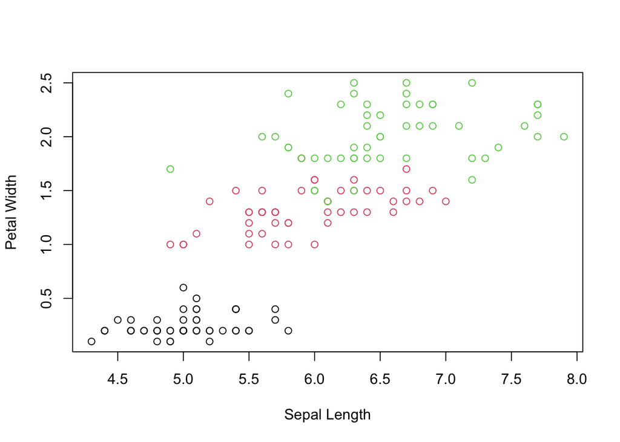

```r
library(ISLR2)
library(fpc)
library(RSSL)
data <- iris
plot(data$Sepal.Length,data$Petal.Width,
  xlab = "Sepal Length", ylab = "Petal Width", col = data$Species)
```

### Question 3

We want only the columns that contain numerical data (subtracting ‘Species’ feature).

```r
km3 <- kmeans(data[,1:4], 3, nstart = 20)
km3$withinss
```

```
## [1] 39.82097 23.87947 15.15100
```

```r
km3$betweenss
```

```
## [1] 602.5192
```

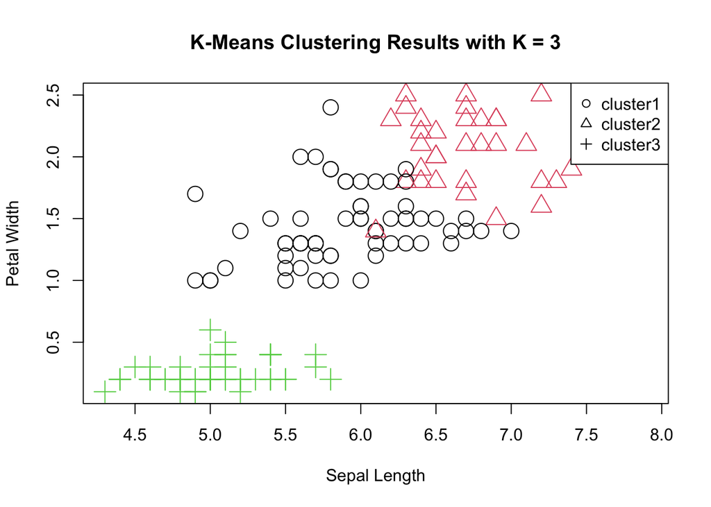

```r
plot(data$Sepal.Length, data$Petal.Width, col = (km3$cluster),
     main = "K-Means Clustering Results with K = 3",xlab = "Sepal Length",
     ylab = "Petal Width", cex = 2, pch=as.numeric(km3$cluster))
legend("topright",c("cluster1","cluster2", "cluster3"), pch=c(1,2,3))
```

### Question 4

##### Plot of K-Means

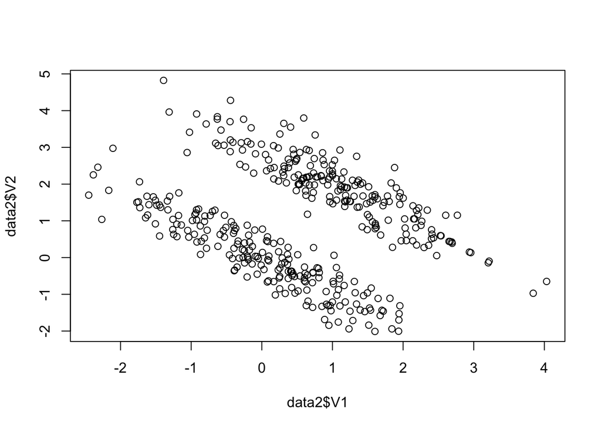

```r
data2 <- read.csv("homework3_clustering.csv")
plot(data2$V1, data2$V2)
```

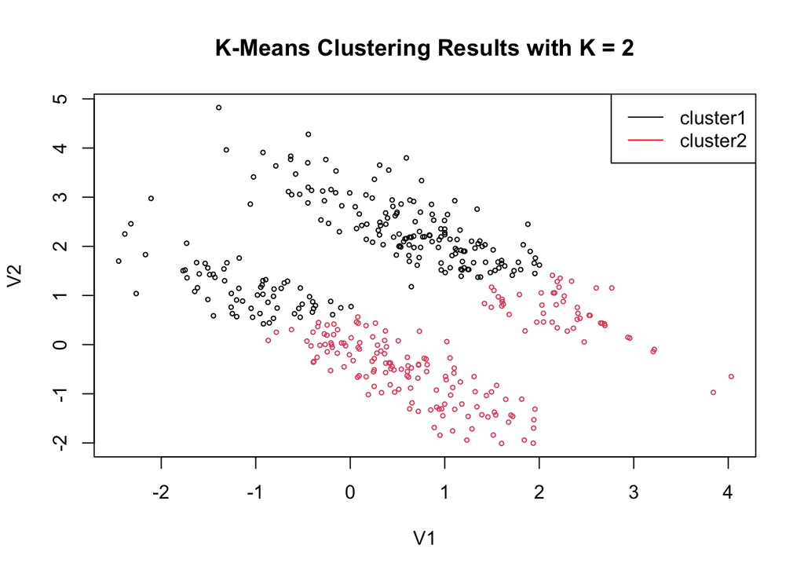

```r
km2 <- kmeans(data2, 2)
plot(data2$V1, data2$V2, col = (km2$cluster),
     main = "K-Means Clustering Results with K = 2",xlab = "V1",
     ylab = "V2", cex = .5, )
legend("topright",c("cluster1","cluster2"), col=c("black", "red"), lty=1:1)
```

##### Plot of DB Scan

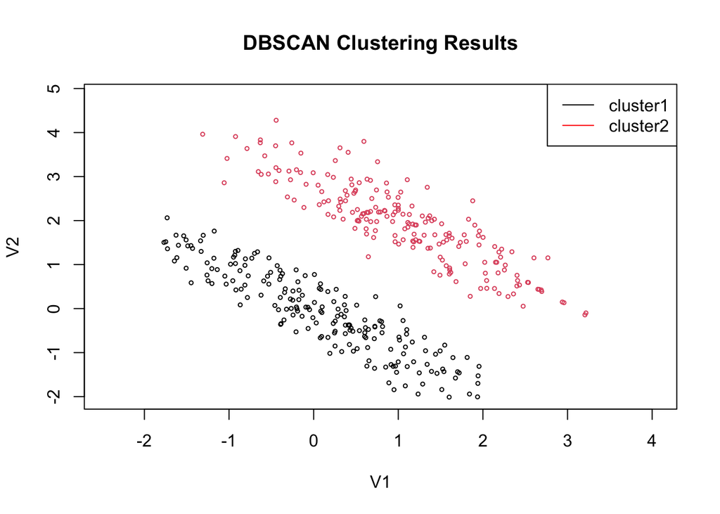

```r
dbscan_data2 <- dbscan(data2, eps = .5, MinPts = 5)
plot(data2$V1, data2$V2, col = dbscan_data2$cluster,
     main = "DBSCAN Clustering Results", xlab = "V1", ylab = "V2", cex = .5)
legend("topright",c("cluster1","cluster2"), col=c("black", "red"), lty=1:1)
```

#### Analysis

This process results in spherical clusting that misrepresents our non-spherical clusters of data. DBSCAN detects alturnitive shapes in the data by identifying clusters based on density. As our data is shaped into two visible elipses, DBSCANS provides us with a much better clustered representation.